# Classification

Erin M. Buchanan

2021-03-31

# Classification

- Text or document classification is an important area of text analytics
- Used to classify, cluster, categorize, or otherwise group documents based on the attributes of that document
- This work is especially useful when you have lots of documents and don’t have the time or energy to read them all!
- This work is not only for documents, but can be applied to music, images, video, etc.

# Classification

- We have called our different functions/programs things like:
  - Taggers: part of speech
  - NER: named entity recognition
  - Parsers: sentence parsing and chunking
- All of these are basically specialized forms of classification
- Now, we will explore how to build a classifier and talk specifically about feature extraction as our focus

# Classification

- The main goal is to take data (documents) that we have and figure out how to classify it
  - The classification labels can be whatever you’d like them to be
  - You can perform this classification based on a prelabeled data (supervised learning) or unlabeled data (unsupervised learning)
- All documents will still need to be “cleaned” or normalized before using classification techniques

# Terminology

- What can I classify?
  - Individual words (often used for sentiment, categories)
  - Phrases/sentences
  - Tweets
  - Documents - often the term document is used to mean any of these, text of varying size

# Terminology

- Often you have a set of predefined “classes” you want to classify documents as
  - Like positive, neutral, negative
  - Sports, fiction, news, academic, etc.
  - Any type of keywords you would like
- Then, in other analyses you are using the documents to help reveal what keywords might be used for classification

# Terminology

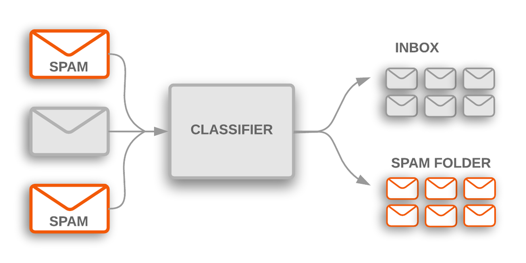

# Types of Techniques

- Unsupervised machine learning:
  - Does not require prelabeled data
  - Focus is on pattern finding, finding latent structures in the data
  - Use feature engineering to find the meaningful patterns
  - Clustering, topic models, factor analysis

# Types of Techniques

- Supervised machine learning:
  - Requires prelabeled data with categories already defined
  - Features are extracted to predict those categories
  - Regression is technically a form of supervised learning - you are trying to predict a continuous outcome
  - Classification is when you are trying to predict a categorical (label) outcome

# Supervised Learning

- First, you will define the feature extraction by determining what might be predictive of your categories
- Next, you will pick an algorithm to use to see if you can map features to category labels
- Once you pick this algorithm, you will use part of the labeled data as *training* data to give your model *learning*
- At this stage, you are improving by tweaking the parameters of the model (hyperparameters)

# Supervised Learning

- After training, you would seek to explore if the model is any good by examining metrics, such as accuracy
- At this stage, you may have a development *testing* set that you can use to improve your model
- After you have completed developing your model, you would measure performance by applying the model to a new *testing* set and examine metrics

# Outcomes

- Binary: two classes or categories, and you assign each document one of their labels
- Multi-class classification: three or more categories, and you assign each document to only one category
- Multi-label classification: you assign documents into one or more labels (like a set of keywords)

# The Process

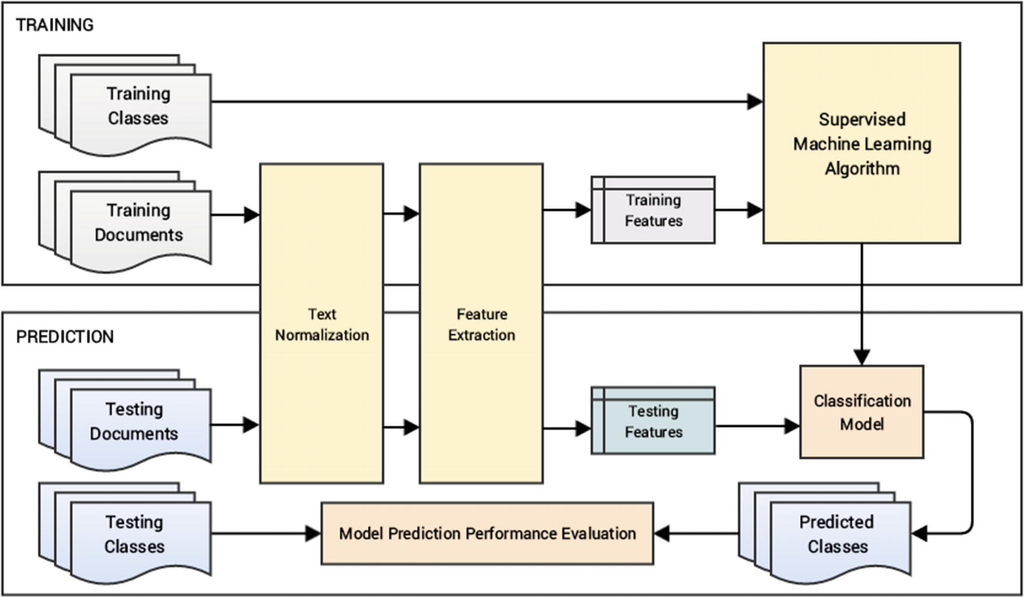

# Working the Process

- Here’s everything we are going to use!

```r
##r chunk
library(reticulate)
py_config()
```

```
## python:         C:/Users/EBuchanan.HU/AppData/Local/r-miniconda/envs/r-reticulate/python.exe
## libpython:      C:/Users/EBuchanan.HU/AppData/Local/r-miniconda/envs/r-reticulate/python36.dll
## pythonhome:     C:/Users/EBuchanan.HU/AppData/Local/r-miniconda/envs/r-reticulate
## version:        3.6.11 (default, Aug  5 2020, 19:41:03) [MSC v.1916 64 bit (AMD64)]
## Architecture:   64bit
## numpy:          C:/Users/EBuchanan.HU/AppData/Local/r-miniconda/envs/r-reticulate/Lib/site-packages/numpy
## numpy_version:  1.18.1
```

```python
##python chunk
import numpy as np
import matplotlib.pyplot as plt
import pandas as pd
from bs4 import BeautifulSoup
from nltk.stem import PorterStemmer
ps = PorterStemmer()
import nltk
stopwords = nltk.corpus.stopwords.words('english')
import unicodedata
from contractions import contractions_dict
```

# 20 Newsgroups

- Difficult classification task if you use all 20 categories
- We need to clean out the formatting, take out empty posts, and do other text processing that we discussed earlier in the semester

```python
data_df = pd.read_csv('20_newsgroups.csv')
data_df.head(10)
```

```
##                                              Article               Target Name
## 0  \n\nI am sure some bashers of Pens fans are pr...          rec.sport.hockey
## 1  My brother is in the market for a high-perform...  comp.sys.ibm.pc.hardware
## 2  \n\n\n\n\tFinally you said what you dream abou...     talk.politics.mideast
## 3  \nThink!\n\nIt's the SCSI card doing the DMA t...  comp.sys.ibm.pc.hardware
## 4  1)    I have an old Jasmine drive which I cann...     comp.sys.mac.hardware
## 5  \n\nBack in high school I worked as a lab assi...           sci.electronics
## 6  \n\nAE is in Dallas...try 214/241-6060 or 214/...     comp.sys.mac.hardware
## 7  \n[stuff deleted]\n\nOk, here's the solution t...          rec.sport.hockey
## 8  \n\n\nYeah, it's the second one.  And I believ...          rec.sport.hockey
## 9  \nIf a Christian means someone who believes in...        talk.religion.misc
```

# Text Normalization

```python
##python chunk
# normalize our corpus

#remove html
data_df['Article'] = [BeautifulSoup(str(text)).get_text() for text in data_df['Article'].tolist()]

#lower case
data_df['Article'] = data_df['Article'].str.lower()

#contractions
#data_df['Article'] = [contractions.fix(text) for text in data_df['Article'].tolist()]
for contraction, expansion in contractions_dict.items():
  data_df['Article'] = data_df['Article'].str.replace(contraction, expansion)

#unicode
data_df['Article'] = [unicodedata.normalize('NFKD', str(text)).encode('ascii', 'ignore').decode('utf-8', 'ignore') for text in data_df['Article'].tolist()]

#take out special characters
data_df['Article'] = data_df['Article'].str.replace('[^a-zA-Z0-9\s]|\[|\]', '')

#stemming
data_df['Article'] = [' '.join([ps.stem(word) for word in text.split()]) for text in data_df['Article'].tolist()]

#stop words
data_df['Article'] = [' '.join([word for word in text.split() if word not in stopwords]) for text in data_df['Article'].tolist()]

#drop the null values after this process
data_df = data_df[~(data_df.Article.str.strip() == '')]
data_df = data_df.dropna().reset_index(drop=True)

#save it
data_df.to_csv('clean_newsgroups.csv', index=False)
```

# Text Normalization

- Let’s look at what our normalization did

```python
##python chunk
data_df = pd.read_csv('clean_newsgroups.csv')
data_df.head()
```

```
##                                              Article               Target Name
## 0  sure basher pen fan pretti confus lack ani kin...          rec.sport.hockey
## 1  brother marchet highperform video card support...  comp.sys.ibm.pc.hardware
## 2  final said dream mediterranean wa new area gre...     talk.politics.mideast
## 3  think scsi card dma transfer disk scsi card dm...  comp.sys.ibm.pc.hardware
## 4  1 old jasmin drive cannot use new system under...     comp.sys.mac.hardware
```

# Build Testing and Training Data

- Let’s split our data into testing and training data with an 80-20% split

```python
##python chunk
from sklearn.model_selection import train_test_split

train_corpus, test_corpus, train_label_names, test_label_names = train_test_split(np.array(data_df['Article'].apply(lambda x:np.str_(x))),
np.array(data_df['Target Name']),
test_size=0.20,
random_state=42)

train_corpus.shape, test_corpus.shape
```

```
## ((14880,), (3721,))
```

# Build Testing and Training Data

- We need to make sure that we don’t have any empty or very small categories
- We can use the counter options to create a frequency table of the splits

```python
##python chunk
from collections import Counter

trd = dict(Counter(train_label_names))
tsd = dict(Counter(test_label_names))

(pd.DataFrame([[key, trd[key], tsd[key]] for key in trd],
             columns=['Target Label', 'Train Count', 'Test Count']).sort_values(by=['Train Count', 'Test Count'], ascending=False))
```

```
##                 Target Label  Train Count  Test Count
## 9     soc.religion.christian          821         169
## 18                 sci.space          794         178
## 7           rec.sport.hockey          793         193
## 5             comp.windows.x          792         181
## 3                  sci.crypt          789         194
## 17           sci.electronics          789         188
## 1                    sci.med          785         195
## 10           rec.motorcycles          783         200
## 8         rec.sport.baseball          779         204
## 11  comp.sys.ibm.pc.hardware          775         196
## 4               misc.forsale          772         190
## 14                 rec.autos          760         216
## 19             comp.graphics          752         205
## 16     comp.sys.mac.hardware          750         199
## 12     talk.politics.mideast          745         181
## 2    comp.os.ms-windows.misc          731         224
## 6         talk.politics.guns          727         173
## 0                alt.atheism          638         158
## 13        talk.politics.misc          613         146
## 15        talk.religion.misc          492         131
```

# Feature Extraction

- What are features?
  - They are measurable (meaning you can put a number to them)
  - Generally, they can be counted or coded as binary (present or not)
  - We have to figure out how to transform text data into features

# Feature Extraction Methods

- Bag of Words method:
  - Create a vector for each document
  - Create a vocabulary of present words
  - Add the frequency, binary encoding, or otherwise denote which words are present in each document

# Feature Extraction Methods

- Bag of N-Grams method:
  - Extend the bag of words but instead of using single words, use phrases or n-grams
  - Careful here because these create more features and smaller frequencies
- TF-IDF method:
  - Term Frequency-Inverse Document Frequency
  - Creates a metric that denotes the importance of a word to a document, given all other documents
  - Weighting scheme that can be applied to Bag of Words type methods

# Advanced Feature Extraction

- There are other methods of vectorizing the data including:
- Word2Vec:
  - Developed by Google
  - This model encodes the data in a neural network model
  - The important component to Word2Vec over simpler feature extraction is that it includes context by using continuous bag of words (CBOW) or Skip Gram encoding
- GloVe and FastText are similar approaches with tweaks on the implementation of Word2Vec options

# Popular Classification Algorithms

- Multinomial Naive Bayes
- Logistic regression
- Support vector machines
- Random forest
- Gradient boosting machine
- … and more! Learn how each of these words by checking out: https://towardsdatascience.com/top-10-machine-learning-algorithms-for-data-science-cdb0400a25f9 and https://becominghuman.ai/top-machine-learning-algorithms-you-should-know-to-become-a-data-scientist-17b16bc85077

# Evaluation

- How do we know we have a good model?
  - Accuracy
  - Precision
  - Recall
  - F1 Score

# Confusion Matrices

- Confusion matrices are a great way to see how your model predicted categories
- Denotes the predicted label versus the actual label
- Great way to see where the model is getting it right and wrong

# Confusion Matrices

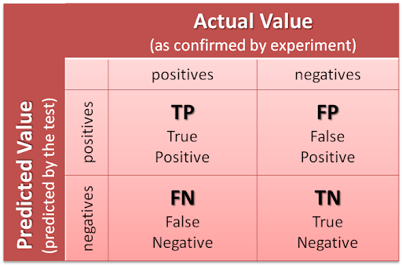

# Confusion Matrices

- True positive: instances TARGET CATEGORY was indicated and it’s actually TARGET CATEGORY
- False positive: instances TARGET CATEGORY was indicated and it’s NOT TARGET CATEGORY
- True negative: instances that TARGET CATEGORY was NOT indicated and it’s NOT TARGET CATEGORY
- False negative: instances that TARGET CATEGORY was NOT indicated and it’s TARGET CATEGORY

# Model Performance - Accuracy

- From these true/false positives and negatives, we can calculate model performance
- Accuracy: Overall proportion of correct predictions in the model

$$\frac{TP + TN}{TP + FP + TN + FN}$$

# Model Performance - Precision

- Precision:
  - Also called positive predictive value
  - Number of times you were right for the positive (1) class

$$\frac{TP}{TP + FP}$$

# Model Performance - Recall

- Recall:
  - Also called sensitivity
  - Identifies the percent of true positives actually captured

$$\frac{TP}{TP + FN}$$

# Model Performance - F1 Score

- F1 Score: harmonic mean of the precision and recall scores

$$\frac{2 \times Precision \times Recall}{Precision + Recall}$$

# General Processing Pipeline

- First, import the packages for your chosen algorithm
- Create a blank model
- Fit the data to the model using the training data
- Predict the categories for the testing data
- Calculate your model performance on the the testing data prediction

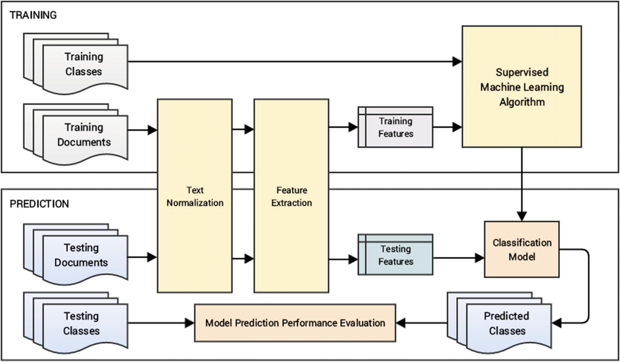

# Example BOW Method

- Let’s first try using the bag of words method to create features for analysis in our classification scheme.
- The `CountVectorizer` function helps us take our processed text and transform it into numerical data.

```python
##python chunk
#packages we need
from sklearn.feature_extraction.text import CountVectorizer
from sklearn.model_selection import cross_val_score

# set up the count vectorizer function
cv = CountVectorizer(binary=False, #not true false, actual counts
                    min_df=0.0, #min proportion words have to occur to be included
                    max_df=1.0, #max proportion
                    decode_error='replace') #take out bad bytes
```

# Example BOW Method

```python
##python chunk
# apply that function to our dataset
# see notes above, make sure this is np.str_
cv_train_features = cv.fit_transform(train_corpus)

# transform test articles into features
cv_test_features = cv.transform(test_corpus)

cv_train_features
```

```
## <14880x71472 sparse matrix of type '<class 'numpy.int64'>'
##  with 888746 stored elements in Compressed Sparse Row format>
```

```python
print('BOW model:> Train features shape:', cv_train_features.shape, ' Test features shape:', cv_test_features.shape)
```

```
## BOW model:> Train features shape: (14880, 71472)  Test features shape: (3721, 71472)
```

# Logistic Regression

- Logistic regression is a popular technique for machine learning and classification tasks
- Binary logistic regression helps classify between two outcomes
- Multinomial logistic regression helps classify between multiple outcomes
- Transforms linear regression to the logit
- Each category will be classified by looking at their predicted probability of being in that category (the odds)

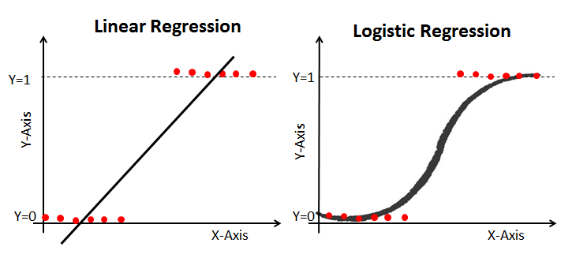

# LR in Python

```python
##python chunk
from sklearn.linear_model import LogisticRegression
from sklearn.metrics import classification_report

#blank model
lr = LogisticRegression(penalty='l2', solver='lbfgs', multi_class='ovr',
                        max_iter=1000, C=1, random_state=42)

#fit the model
lr.fit(cv_train_features, train_label_names)

#predict new cases
```

```
## LogisticRegression(C=1, max_iter=1000, multi_class='ovr', random_state=42)
```

```python
y_pred = lr.predict(cv_test_features)

#print out results
print(classification_report(test_label_names, y_pred))
```

```
##                           precision    recall  f1-score   support
##
##              alt.atheism       0.62      0.59      0.61       158
##            comp.graphics       0.64      0.63      0.64       205
##  comp.os.ms-windows.misc       0.68      0.65      0.67       224
## comp.sys.ibm.pc.hardware       0.62      0.67      0.65       196
##    comp.sys.mac.hardware       0.76      0.70      0.73       199
##           comp.windows.x       0.73      0.70      0.71       181
##             misc.forsale       0.80      0.77      0.78       190
##                rec.autos       0.60      0.74      0.66       216
##          rec.motorcycles       0.62      0.77      0.69       200
##       rec.sport.baseball       0.81      0.79      0.80       204
##         rec.sport.hockey       0.85      0.85      0.85       193
##                sci.crypt       0.79      0.75      0.77       194
##          sci.electronics       0.62      0.68      0.65       188
##                  sci.med       0.83      0.77      0.80       195
##                sci.space       0.74      0.71      0.73       178
##   soc.religion.christian       0.66      0.70      0.68       169
##       talk.politics.guns       0.67      0.70      0.69       173
##    talk.politics.mideast       0.83      0.77      0.80       181
##       talk.politics.misc       0.64      0.60      0.61       146
##       talk.religion.misc       0.49      0.32      0.39       131
##
##                 accuracy                           0.70      3721
##                macro avg       0.70      0.69      0.69      3721
##             weighted avg       0.70      0.70      0.70      3721
```

# Naive Bayes

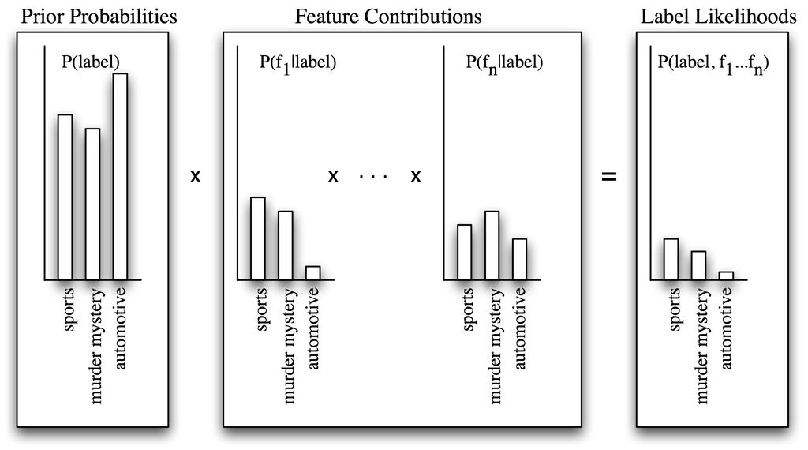

# Multinomial Naive Bayes in Python

```python
##python chunk
from sklearn.naive_bayes import MultinomialNB

mnb = MultinomialNB(alpha=1)
```

# MNB in Python

```python
#fit the model
mnb.fit(cv_train_features, train_label_names)

#predict new cases
```

```
## MultinomialNB(alpha=1)
```

```python
y_pred = mnb.predict(cv_test_features)

#print out results
print(classification_report(test_label_names, y_pred))
```

```
##                           precision    recall  f1-score   support
##
##              alt.atheism       0.76      0.35      0.48       158
##            comp.graphics       0.74      0.69      0.71       205
##  comp.os.ms-windows.misc       0.79      0.58      0.67       224
## comp.sys.ibm.pc.hardware       0.62      0.78      0.69       196
##    comp.sys.mac.hardware       0.84      0.68      0.75       199
##           comp.windows.x       0.78      0.77      0.78       181
##             misc.forsale       0.84      0.69      0.76       190
##                rec.autos       0.64      0.78      0.70       216
##          rec.motorcycles       0.90      0.67      0.76       200
##       rec.sport.baseball       0.90      0.84      0.87       204
##         rec.sport.hockey       0.92      0.85      0.88       193
##                sci.crypt       0.67      0.84      0.75       194
##          sci.electronics       0.76      0.65      0.70       188
##                  sci.med       0.88      0.82      0.85       195
##                sci.space       0.76      0.74      0.75       178
##   soc.religion.christian       0.36      0.94      0.52       169
##       talk.politics.guns       0.63      0.76      0.69       173
##    talk.politics.mideast       0.80      0.83      0.82       181
##       talk.politics.misc       0.64      0.68      0.66       146
##       talk.religion.misc       0.54      0.05      0.10       131
##
##                 accuracy                           0.71      3721
##                macro avg       0.74      0.70      0.69      3721
##             weighted avg       0.75      0.71      0.71      3721
```

# Linear Support Vector Machine (SVM)

- An algorithm to separate categories by the largest amount on a hyperplane
- Support vectors are the data points closest to the hyperplane
- Hyperplane is the decision plane that separates the set of categories

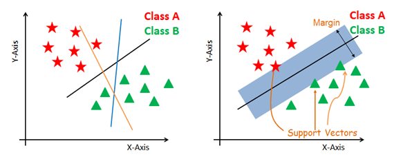

# SVM in Python

```python
##python chunk
from sklearn.svm import LinearSVC

svm = LinearSVC(penalty='l2', C=1, random_state=42, max_iter = 10000)
svm.fit(cv_train_features, train_label_names)
```

```
## LinearSVC(C=1, max_iter=10000, random_state=42)
##
```

```python
y_pred = svm.predict(cv_test_features)

#print out results
print(classification_report(test_label_names, y_pred))
```

```
##                           precision    recall  f1-score   support
##
##              alt.atheism       0.58      0.51      0.54       158
##            comp.graphics       0.62      0.60      0.61       205
##  comp.os.ms-windows.misc       0.69      0.61      0.64       224
## comp.sys.ibm.pc.hardware       0.58      0.65      0.61       196
##    comp.sys.mac.hardware       0.66      0.66      0.66       199
##           comp.windows.x       0.70      0.66      0.68       181
##             misc.forsale       0.75      0.72      0.73       190
##                rec.autos       0.56      0.69      0.62       216
##          rec.motorcycles       0.57      0.69      0.63       200
##       rec.sport.baseball       0.79      0.74      0.77       204
##         rec.sport.hockey       0.81      0.83      0.82       193
##                sci.crypt       0.76      0.70      0.73       194
##          sci.electronics       0.59      0.60      0.59       188
##                  sci.med       0.79      0.72      0.76       195
##                sci.space       0.68      0.71      0.69       178
##   soc.religion.christian       0.64      0.66      0.65       169
##       talk.politics.guns       0.60      0.61      0.60       173
##    talk.politics.mideast       0.76      0.74      0.75       181
##       talk.politics.misc       0.53      0.53      0.53       146
##       talk.religion.misc       0.46      0.37      0.41       131
##
##                 accuracy                           0.66      3721
##                macro avg       0.66      0.65      0.65      3721
##             weighted avg       0.66      0.66      0.66      3721
```

# The Results

- All three give us approximately the same results
- Accuracy is about 70%, which is pretty good considering the number of categories
- Can we improve by selecting a better set of features?

# TF-IDF

- Remember the TF-IDF is a weighting scheme that lessens the importance of very frequent and very infrequent words

```python
##python chunk
from sklearn.feature_extraction.text import TfidfVectorizer

# build BOW with TFIDF features on train articles
tv = TfidfVectorizer(use_idf=True, min_df=0.0, max_df=1.0)

# apply to train and test
tv_train_features = tv.fit_transform(train_corpus)
tv_test_features = tv.transform(test_corpus)

# look at feature shape
print('TFIDF model:> Train features shape:', tv_train_features.shape, ' Test features shape:', tv_test_features.shape)
```

```
## TFIDF model:> Train features shape: (14880, 71472)  Test features shape: (3721, 71472)
```

# Retest LR

```python
##python chunk
lr = LogisticRegression(penalty='l2', solver='lbfgs', multi_class='ovr',
                        max_iter=1000, C=1, random_state=42)
lr.fit(tv_train_features, train_label_names)
```

```
## LogisticRegression(C=1, max_iter=1000, multi_class='ovr', random_state=42)
```

```python
y_pred = lr.predict(tv_test_features)
print(classification_report(test_label_names, y_pred))
```

```
##                           precision    recall  f1-score   support
##
##              alt.atheism       0.68      0.60      0.64       158
##            comp.graphics       0.65      0.70      0.67       205
##  comp.os.ms-windows.misc       0.72      0.66      0.69       224
## comp.sys.ibm.pc.hardware       0.70      0.68      0.69       196
##    comp.sys.mac.hardware       0.82      0.69      0.75       199
##           comp.windows.x       0.76      0.75      0.76       181
##             misc.forsale       0.77      0.78      0.77       190
##                rec.autos       0.62      0.79      0.70       216
##          rec.motorcycles       0.68      0.81      0.74       200
##       rec.sport.baseball       0.86      0.82      0.84       204
##         rec.sport.hockey       0.89      0.90      0.89       193
##                sci.crypt       0.86      0.75      0.80       194
##          sci.electronics       0.60      0.71      0.65       188
##                  sci.med       0.83      0.85      0.84       195
##                sci.space       0.77      0.79      0.78       178
##   soc.religion.christian       0.64      0.84      0.72       169
##       talk.politics.guns       0.69      0.76      0.72       173
##    talk.politics.mideast       0.86      0.80      0.83       181
##       talk.politics.misc       0.70      0.70      0.70       146
##       talk.religion.misc       0.67      0.17      0.27       131
##
##                 accuracy                           0.74      3721
##                macro avg       0.74      0.73      0.72      3721
##             weighted avg       0.74      0.74      0.73      3721
```

# Retest MNB

```python
##python chunk
mnb.fit(tv_train_features, train_label_names)
```

```
## MultinomialNB(alpha=1)
```

```python
y_pred = mnb.predict(tv_test_features)
print(classification_report(test_label_names, y_pred))
```

```
##                           precision    recall  f1-score   support
##
##              alt.atheism       0.94      0.19      0.32       158
##            comp.graphics       0.72      0.65      0.68       205
##  comp.os.ms-windows.misc       0.78      0.58      0.67       224
## comp.sys.ibm.pc.hardware       0.61      0.78      0.68       196
##    comp.sys.mac.hardware       0.84      0.73      0.78       199
##           comp.windows.x       0.80      0.80      0.80       181
##             misc.forsale       0.86      0.72      0.78       190
##                rec.autos       0.65      0.79      0.71       216
##          rec.motorcycles       0.87      0.74      0.80       200
##       rec.sport.baseball       0.91      0.83      0.87       204
##         rec.sport.hockey       0.87      0.90      0.88       193
##                sci.crypt       0.64      0.87      0.73       194
##          sci.electronics       0.72      0.67      0.69       188
##                  sci.med       0.92      0.79      0.85       195
##                sci.space       0.80      0.77      0.78       178
##   soc.religion.christian       0.31      0.94      0.46       169
##       talk.politics.guns       0.64      0.79      0.70       173
##    talk.politics.mideast       0.87      0.83      0.85       181
##       talk.politics.misc       0.92      0.38      0.54       146
##       talk.religion.misc       0.75      0.02      0.04       131
##
##                 accuracy                           0.71      3721
##                macro avg       0.77      0.69      0.68      3721
##             weighted avg       0.77      0.71      0.70      3721
```

# Retest SVM

```python
##python chunk
svm = LinearSVC(penalty='l2', C=1, random_state=42)
svm.fit(tv_train_features, train_label_names)
```

```
## LinearSVC(C=1, random_state=42)
```

```python
y_pred = svm.predict(tv_test_features)
print(classification_report(test_label_names, y_pred))
```

```
##                           precision    recall  f1-score   support
##
##              alt.atheism       0.71      0.64      0.67       158
##            comp.graphics       0.74      0.72      0.73       205
##  comp.os.ms-windows.misc       0.75      0.70      0.72       224
## comp.sys.ibm.pc.hardware       0.68      0.71      0.69       196
##    comp.sys.mac.hardware       0.82      0.77      0.79       199
##           comp.windows.x       0.80      0.80      0.80       181
##             misc.forsale       0.83      0.78      0.80       190
##                rec.autos       0.65      0.81      0.72       216
##          rec.motorcycles       0.80      0.81      0.80       200
##       rec.sport.baseball       0.87      0.83      0.85       204
##         rec.sport.hockey       0.89      0.88      0.88       193
##                sci.crypt       0.83      0.80      0.81       194
##          sci.electronics       0.68      0.73      0.70       188
##                  sci.med       0.85      0.85      0.85       195
##                sci.space       0.78      0.78      0.78       178
##   soc.religion.christian       0.65      0.80      0.72       169
##       talk.politics.guns       0.71      0.73      0.72       173
##    talk.politics.mideast       0.84      0.83      0.84       181
##       talk.politics.misc       0.66      0.70      0.68       146
##       talk.religion.misc       0.60      0.34      0.44       131
##
##                 accuracy                           0.76      3721
##                macro avg       0.76      0.75      0.75      3721
##             weighted avg       0.76      0.76      0.76      3721
```

# Where are we incorrect?

```python
##python chunk
#note I had to upgrade sklearn to .22 for this
from sklearn import metrics
metrics.confusion_matrix(test_label_names, y_pred)
```

```
## array([[101,   0,   1,   1,   0,   0,   0,   3,   4,   2,   0,   3,   3,
##           1,   3,  17,   4,   3,   3,   9],
##        [  0, 148,   7,   6,   2,  15,   3,   7,   1,   1,   0,   3,   4,
##           1,   3,   1,   1,   0,   2,   0],
##        [  1,  14, 156,  18,   4,   7,   1,   7,   2,   0,   1,   1,   3,
##           1,   2,   0,   3,   2,   1,   0],
##        [  0,   4,  16, 139,  14,   1,   7,   5,   0,   0,   0,   0,   6,
##           0,   1,   2,   0,   0,   1,   0],
##        [  0,   3,   6,   8, 153,   3,   5,   5,   1,   2,   0,   1,   4,
##           2,   3,   2,   1,   0,   0,   0],
##        [  0,  12,   5,   3,   1, 144,   1,   0,   1,   0,   3,   3,   4,
##           1,   1,   0,   0,   1,   1,   0],
##        [  1,   1,   2,   9,   2,   1, 148,   6,   1,   3,   1,   0,  10,
##           1,   0,   1,   1,   1,   1,   0],
##        [  1,   2,   1,   3,   1,   0,   4, 175,   9,   0,   2,   1,   6,
##           1,   1,   0,   2,   2,   4,   1],
##        [  0,   0,   1,   1,   4,   0,   1,   9, 162,   1,   2,   0,   5,
##           0,   5,   4,   1,   1,   3,   0],
##        [  3,   2,   2,   0,   1,   0,   1,   6,   5, 170,   7,   0,   1,
##           1,   1,   0,   2,   2,   0,   0],
##        [  0,   0,   0,   0,   0,   2,   0,   6,   2,   4, 170,   1,   0,
##           1,   1,   1,   2,   2,   0,   1],
##        [  1,   3,   0,   1,   1,   1,   0,   7,   2,   1,   1, 155,   5,
##           1,   2,   2,   3,   3,   3,   2],
##        [  1,   2,   1,  11,   4,   3,   3,   6,   3,   1,   2,   3, 137,
##           2,   5,   0,   1,   1,   1,   1],
##        [  0,   5,   2,   1,   0,   0,   0,   6,   0,   0,   0,   1,   5,
##         165,   1,   2,   2,   2,   1,   2],
##        [  2,   3,   2,   1,   0,   0,   2,   2,   2,   4,   1,   1,   5,
##           4, 139,   2,   2,   0,   5,   1],
##        [  9,   1,   1,   2,   0,   0,   2,   2,   0,   0,   0,   0,   0,
##           3,   1, 136,   1,   3,   3,   5],
##        [  1,   0,   1,   0,   0,   2,   0,   6,   2,   3,   1,   4,   2,
##           2,   4,   3, 127,   0,  12,   3],
##        [  3,   0,   0,   0,   0,   0,   0,   3,   1,   0,   1,   6,   1,
##           1,   1,   3,   4, 151,   6,   0],
##        [  4,   0,   3,   0,   0,   0,   0,   3,   3,   3,   0,   3,   0,
##           3,   4,   1,   9,   3, 102,   5],
##        [ 15,   1,   1,   0,   0,   0,   1,   7,   2,   1,   0,   1,   0,
##           3,   1,  31,  13,   3,   6,  45]], dtype=int64)
```

```python
metrics.plot_confusion_matrix(svm, #model classifier
                              X = tv_test_features, #features
                              y_true = test_label_names, #answers
                              xticks_rotation = "vertical")
```

```
## <sklearn.metrics._plot.confusion_matrix.ConfusionMatrixDisplay object at 0x0000000005522668>
```

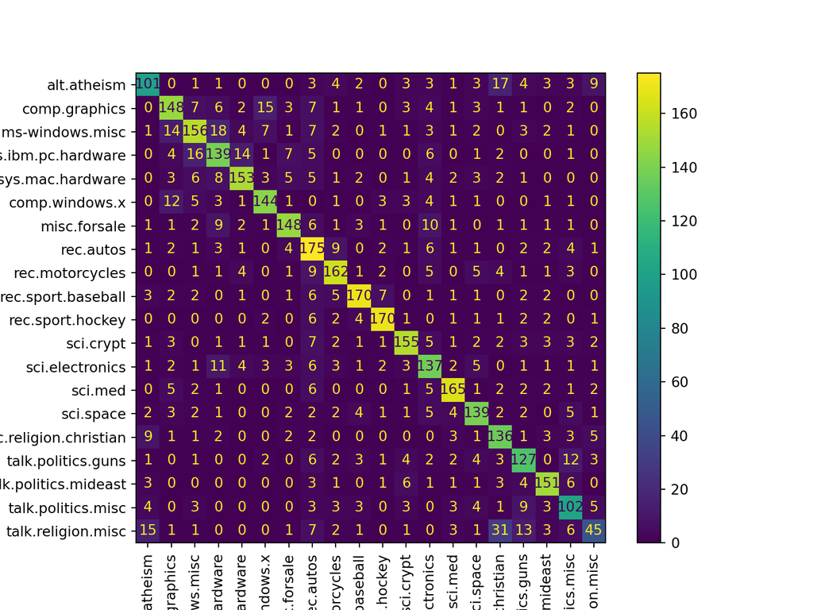

```python
plt.show()
```

# word2vec is a Neural Net

- word2vec extends our bag of words models into a neural net models
- Neural net models try to represent the way that neurons work in the brain
- They are organized by layers which show the interconnected processes occurring in cognition
- The nodes are connected via weights, which are adjusted with training

# Example visualization

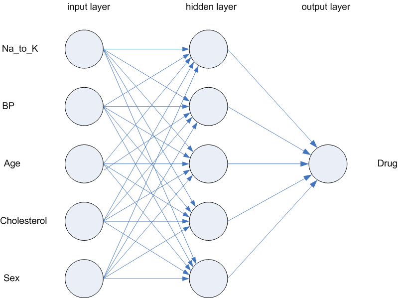

# Features in word2vec

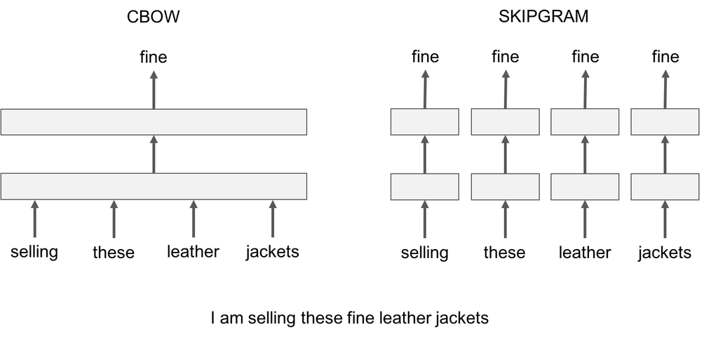

# Implementing word2vec

- First, take your corpus and tokenize the words, so you have a list of lists

```python
##python chunk
tokenized_train = [nltk.tokenize.word_tokenize(text)
                   for text in train_corpus]
tokenized_test = [nltk.tokenize.word_tokenize(text)
                   for text in test_corpus]
```

# Build a word2vec

```python
##python chunk
import gensim
# build word2vec model
w2v_num_features = 300
w2v_model = gensim.models.Word2Vec(tokenized_train, #corpus
            size=w2v_num_features, #number of features
            window=10, #size of moving window
            min_count=2, #minimum number of times to run
            sg = 0, #cbow model
            iter=5, workers=5) #iterations and cores
```

# Convert to features

```python
##python chunk
#create flattening function
def document_vectorizer(corpus, model, num_features):
    vocabulary = set(model.wv.index2word)

    def average_word_vectors(words, model, vocabulary, num_features):
        feature_vector = np.zeros((num_features,), dtype="float64")
        nwords = 0.

        for word in words:
            if word in vocabulary:
                nwords = nwords + 1.
                feature_vector = np.add(feature_vector, model.wv[word])
        if nwords:
            feature_vector = np.divide(feature_vector, nwords)

        return feature_vector

    features = [average_word_vectors(tokenized_sentence, model, vocabulary, num_features)
                    for tokenized_sentence in corpus]
    return np.array(features)

# generate averaged word vector features from word2vec model
avg_wv_train_features = document_vectorizer(corpus=tokenized_train, model=w2v_model,
                                                     num_features=w2v_num_features)
avg_wv_test_features = document_vectorizer(corpus=tokenized_test, model=w2v_model,
                                                    num_features=w2v_num_features)
```

# Test with your algorithms

```python
##python chunk
lr = LogisticRegression(penalty='l2', solver='lbfgs', multi_class='ovr',
                        max_iter=1000, C=1, random_state=42)
lr.fit(avg_wv_train_features, train_label_names)
```

```
## LogisticRegression(C=1, max_iter=1000, multi_class='ovr', random_state=42)
```

```python
y_pred = lr.predict(avg_wv_test_features)
print(classification_report(test_label_names, y_pred))
```

```
##                           precision    recall  f1-score   support
##
##              alt.atheism       0.37      0.31      0.34       158
##            comp.graphics       0.49      0.44      0.47       205
##  comp.os.ms-windows.misc       0.55      0.42      0.48       224
## comp.sys.ibm.pc.hardware       0.42      0.47      0.45       196
##    comp.sys.mac.hardware       0.44      0.28      0.34       199
##           comp.windows.x       0.53      0.60      0.56       181
##             misc.forsale       0.62      0.79      0.70       190
##                rec.autos       0.59      0.41      0.48       216
##          rec.motorcycles       0.37      0.51      0.43       200
##       rec.sport.baseball       0.51      0.34      0.41       204
##         rec.sport.hockey       0.57      0.76      0.65       193
##                sci.crypt       0.58      0.65      0.62       194
##          sci.electronics       0.46      0.33      0.38       188
##                  sci.med       0.38      0.63      0.47       195
##                sci.space       0.47      0.60      0.53       178
##   soc.religion.christian       0.47      0.73      0.58       169
##       talk.politics.guns       0.48      0.55      0.51       173
##    talk.politics.mideast       0.63      0.74      0.68       181
##       talk.politics.misc       0.31      0.09      0.14       146
##       talk.religion.misc       0.25      0.01      0.01       131
##
##                 accuracy                           0.49      3721
##                macro avg       0.47      0.48      0.46      3721
##             weighted avg       0.48      0.49      0.47      3721
```

# Test with Bayes

```python
##python chunk
#specifically Bayes does not allow negative numbers

#find the minimum values
avg_wv_train_features.min()
```

```
## -2.910034656524658
```

```python
avg_wv_test_features.min()

#add a constant to both
```

```
## -2.910034656524658
```

```python
avg_wv_train_features = avg_wv_train_features + 4
avg_wv_test_features = avg_wv_test_features + 4

#then run bayes
mnb = MultinomialNB(alpha=1)
mnb.fit(avg_wv_train_features, train_label_names)
```

```
## MultinomialNB(alpha=1)
```

```python
y_pred = mnb.predict(avg_wv_test_features)
print(classification_report(test_label_names, y_pred))
```

```
##                           precision    recall  f1-score   support
##
##              alt.atheism       0.00      0.00      0.00       158
##            comp.graphics       0.30      0.19      0.23       205
##  comp.os.ms-windows.misc       0.51      0.18      0.26       224
## comp.sys.ibm.pc.hardware       0.35      0.56      0.43       196
##    comp.sys.mac.hardware       0.26      0.04      0.06       199
##           comp.windows.x       0.38      0.62      0.47       181
##             misc.forsale       0.50      0.58      0.54       190
##                rec.autos       0.43      0.11      0.17       216
##          rec.motorcycles       0.26      0.48      0.34       200
##       rec.sport.baseball       0.42      0.35      0.38       204
##         rec.sport.hockey       0.47      0.53      0.50       193
##                sci.crypt       0.49      0.54      0.51       194
##          sci.electronics       0.23      0.30      0.26       188
##                  sci.med       0.31      0.39      0.35       195
##                sci.space       0.22      0.40      0.29       178
##   soc.religion.christian       0.29      0.82      0.43       169
##       talk.politics.guns       0.38      0.31      0.34       173
##    talk.politics.mideast       0.55      0.63      0.58       181
##       talk.politics.misc       0.00      0.00      0.00       146
##       talk.religion.misc       0.00      0.00      0.00       131
##
##                 accuracy                           0.36      3721
##                macro avg       0.32      0.35      0.31      3721
##             weighted avg       0.33      0.36      0.32      3721
##
##
```

# Test with SVM

```python
svm = LinearSVC(penalty='l2', C=1, random_state=42)
svm.fit(avg_wv_train_features, train_label_names)
```

```
## LinearSVC(C=1, random_state=42)
##
```

```python
y_pred = svm.predict(avg_wv_test_features)

#print out results
print(classification_report(test_label_names, y_pred))
```

```
##                           precision    recall  f1-score   support
##
##              alt.atheism       0.32      0.48      0.39       158
##            comp.graphics       0.35      0.54      0.43       205
##  comp.os.ms-windows.misc       0.68      0.08      0.14       224
## comp.sys.ibm.pc.hardware       0.64      0.07      0.13       196
##    comp.sys.mac.hardware       0.33      0.60      0.42       199
##           comp.windows.x       0.28      0.80      0.41       181
##             misc.forsale       0.75      0.64      0.69       190
##                rec.autos       0.49      0.36      0.41       216
##          rec.motorcycles       0.23      0.71      0.35       200
##       rec.sport.baseball       0.57      0.52      0.54       204
##         rec.sport.hockey       0.71      0.54      0.61       193
##                sci.crypt       0.74      0.59      0.65       194
##          sci.electronics       0.52      0.22      0.31       188
##                  sci.med       0.70      0.32      0.44       195
##                sci.space       0.71      0.43      0.53       178
##   soc.religion.christian       0.54      0.56      0.55       169
##       talk.politics.guns       0.40      0.61      0.49       173
##    talk.politics.mideast       0.87      0.57      0.69       181
##       talk.politics.misc       0.00      0.00      0.00       146
##       talk.religion.misc       0.00      0.00      0.00       131
##
##                 accuracy                           0.44      3721
##                macro avg       0.49      0.43      0.41      3721
##             weighted avg       0.51      0.44      0.42      3721
##
##
```

# Summary

- We have examined the different options for classification
  - Focusing on feature representation for words
  - Focusing on algorithm
- We find that features do have an impact on the outcome, as well as the algorithm